# Integrated Umap & Marker Genes

In this .Rmd, we reproduce panel b from figure 2. For this we visualized the integrated the targeted Gene expression data from Library Alpha & Library Beta screen (panel b) & Additional File 1 Figure 9.

# 1 Marker Genes

```r
#load file with LibAlpha & BetaScreen integrated Gex
integrated <- readRDS("~/cluster/project/SCG4SYN/Experiments/240524_scMPRA_LibBeta_HSC_iseq/screen_HSC/002_analysis/paper_figures/files_figshare/integrated_seurat.rds")
```

First, we plot relevant marker genes to annotate the cell types of the ex vivo HSPC cultures. Interesting marker genes are Ctss, S100a9, Gata1, Gata2, Mpo, Cd34, H2eb1, Cebpa, Cebpe, Kel, Spi1, Fli1, Runx1, Meis1, Myb, Myc, Hbbbt, Klf1, Klf4, Itga2b, Mki67, Fcer1a, Mcpt8.

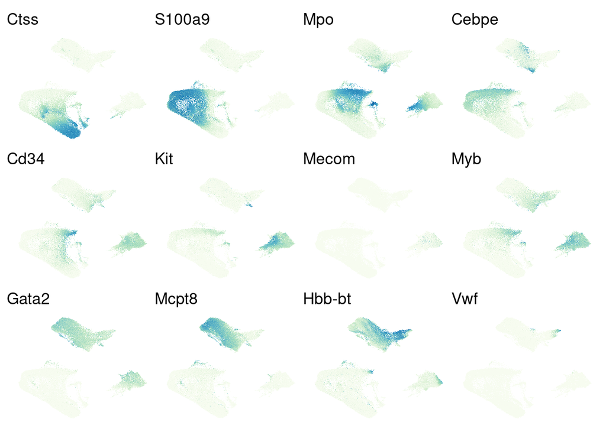

```r
#this is a subselection of the interesting marker genes
plots <- FeaturePlot(integrated,
                     features = c("Ctss", "S100a9", "Mpo", "Cebpe", "Cd34", "Kit", "Mecom", "Myb",
                                  "Gata2", "Mcpt8", "Hbb-bt", "Vwf"),
                     order = TRUE)  #,raster = TRUE)

# Apply the color scale to all plots
plots <- lapply(plots, function(p) {
  p +
    scale_colour_gradientn(colours = brewer.pal(n = 9, name = "GnBu")) +
    theme_void() +
    NoLegend()
})
# Combine and show the plots (using patchwork or cowplot)
marker_genes_panel <- wrap_plots(plots, ncol = 4)

#ggsave("./008_hspcs_markers.png", marker_genes_panel, width=16, height=12, device = "png", units = "cm")

marker_genes_panel
```

# 2 Cell type annotation

Here we are plotting the labels on the annotated umap.

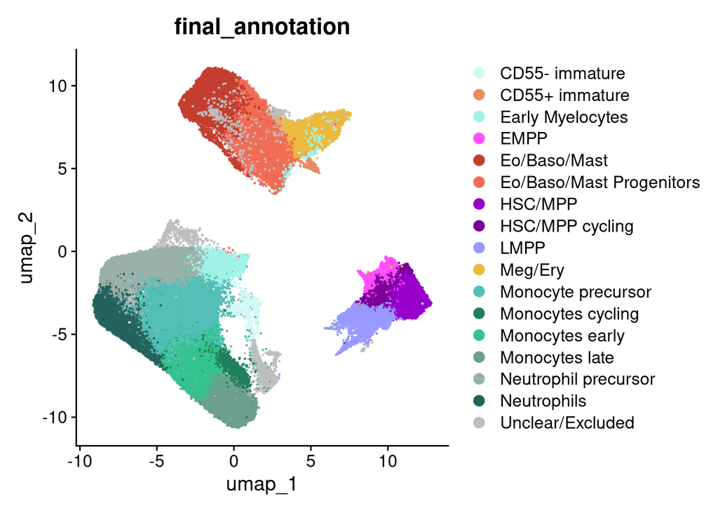

```r
#cell type annotation
set.seed(456)

another_pal<- c("Eo/Baso/Mast" = "#C43E2F",
                "Eo/Baso/Mast Progenitors" =  "#F26B55" ,
                "CD55+ immature" = "#E78C64",
                "Meg/Ery" = "#EDB93E",
                "Monocytes late" = "#6C9F8C",
                "Monocytes cycling" = "#217F5C",
                "Monocytes early" = "#33C38E",
                "Neutrophils" = "#25625E",
                "Early Myelocytes" = "#A0F2E8",
                "Monocyte precursor" = "#54BFB7",
                "Unclear/Excluded" = "grey",
                "Neutrophil precursor" = "#9ab1a9",
                "CD55- immature" = "#d2f9f4",
                "EMPP" = "#ff4dff",
                "LMPP" = "#9999ff",
                "HSC/MPP cycling" = "#7a0099",
                "HSC/MPP" = "#9900cc")


cell_types <- DimPlot(integrated, group.by = c("final_annotation"), na.value = "grey", label=F, raster = FALSE) + scale_color_manual(values = another_pal)

#ggsave("./008_hspcs_celltype_anno.png", cell_types, width=16, height=12, device = "png", units = "cm")

cell_types
```

# 3 Integration using Scanorama

Here I provide the code that was used to integrate the cells from the Library Alpha (Trp53) and the Library Beta (Cebpa) screen and obtain the integrated Seurat object that we use above and that is shared on figshare.

```r
#activate conda env
use_condaenv("scanorama")
scanorama <- import('scanorama')

#integrate load the two different seurat objects from the LibAlpha (Trp53) and LibBeta screen (Cebpa)
Cebpa <- readRDS("/users/lvelten/project/SCG4SYN/Experiments/250528_scMPRA_LibGamma_HSC/screen_HSC/002_analysis/scMPRA11_qced_all_layers.RDS")
Trp53 <- readRDS("/users/lvelten/project/SCG4SYN/Experiments/240524_scMPRA_LibBeta_HSC_iseq/screen_HSC/002_analysis/001_integration/scMPRA4_11qced_all_layers_wo9.RDS")
```

Now, we can perform the scanorama integration based on the genes that we selected for the targeting panel (Additional Files).

```r
#1. perform scanorama integration
cebpa_matrix <- GetAssayData(Cebpa)
nonzero_cebpa <- rowMeans(cebpa_matrix > 0)

trp53_matrix <- GetAssayData(Trp53)
nonzero_trp53 <- rowMeans(trp53_matrix > 0)

use_genes <- read.csv("/users/lvelten/project/SCG4SYN/Experiments/220923_5TAP_panel_scMPRA/HSC_panel/HSC_panel_selected_genes.csv") %>% unlist() %>% as.vector()
use_genes <- intersect(intersect(use_genes, rownames(cebpa_matrix)), rownames(trp53_matrix))


for_scanorama <- list(t(as.matrix(trp53_matrix[use_genes,])), t(as.matrix(cebpa_matrix[use_genes,])))

integrated.corrected.data <- scanorama$correct(for_scanorama, lapply(for_scanorama, colnames),return_dimred=TRUE, return_dense=TRUE, verbose = TRUE)
```

Next, we assemble a new seurat object. For each of the two joined seurat objects we do three things: 1. extract raw count matrix from RNA assay 2. keeps only targeted genes 3. renames the cell barcodes by prefixing them with the dataset name

```r
#2. assemble a new seurat object
seurat_objects <- list(Trp53 = Trp53, Cebpa = Cebpa)
RNA_counts <- lapply(names(seurat_objects), function(n) { out <- GetAssayData(seurat_objects[[n]],layer = "counts")[use_genes,]; colnames(out) <- paste0(n, ".", colnames(out)); out })
names(for_scanorama) <- c("Trp53", "Cebpa")
RNA_scaled <- lapply(names(for_scanorama), function(n) { out <- t(for_scanorama[[n]]); colnames(out) <- paste0(n, ".", colnames(out)); out }) #uses SCT scaling in RNA

RNA <- CreateAssay5Object(counts = do.call(cbind, RNA_counts), data = do.call(cbind, RNA_scaled), min.cells = 0, min.features = 0)

integrated <- CreateSeuratObject(RNA, "RNA")
scanorama_matrix <- do.call(rbind, integrated.corrected.data[[1]])
rownames(scanorama_matrix) <- colnames(RNA)
integrated[["scanorama"]] <- CreateDimReducObject(embeddings = scanorama_matrix, assay = "RNA", key = "SCAN_")
integrated$experiment <- gsub("\\..+", "", colnames(integrated))
integrated <- RunUMAP(integrated, reduction = "scanorama", dims = 1:100)
```

```r
#3. Add metadata
metadata_trp53 <- Trp53@meta.data
metadata_cepba <- Cebpa@meta.data
clusterings <- union(colnames(metadata_cepba), colnames(metadata_trp53))
clusterings <- clusterings[grepl("SCT_snn", clusterings)]
clustering_matrix <- matrix(NA, nrow = ncol(integrated), ncol = length(clusterings), dimnames = list(colnames(integrated), clusterings))
clustering_matrix[grepl("Trp53", rownames(clustering_matrix)), clusterings[clusterings %in% colnames(metadata_trp53)]] <- as.matrix(metadata_trp53[,clusterings[clusterings %in% colnames(metadata_trp53)]])
clustering_matrix[grepl("Cebpa", rownames(clustering_matrix)), clusterings[clusterings %in% colnames(metadata_cepba)]] <- as.matrix(metadata_cepba[,clusterings[clusterings %in% colnames(metadata_cepba)]])
integrated <- AddMetaData(integrated, clustering_matrix)

celltype_anno <- matrix(NA,nrow = ncol(integrated), ncol = 2,dimnames = list(colnames(integrated), c("annotation_Trp53", "annotation_Cebpa")))
celltype_anno[grepl("Trp53", rownames(clustering_matrix)), "annotation_Trp53"] <- as.character(metadata_trp53$cell_types)
celltype_anno[grepl("Cebpa", rownames(clustering_matrix)), "annotation_Cebpa"] <- as.character(metadata_cepba$celltype_anno)
integrated <- AddMetaData(integrated, celltype_anno)

#Annotate cell types
integrated <- FindNeighbors(integrated, reduction =  "scanorama", dims = 1:100)
integrated <- FindClusters(integrated)

#saveRDS(integrated, file = "./integrated.RDS")

# png("integrated_umaps.png",width=1400,height=800, res=100)
# DimPlot(integrated, group.by = c("experiment","annotation_Trp53", "annotation_Cebpa", "ident"), na.value = "grey", label=T, ncol=2)
# dev.off()
```